# Retail Project

Harsh Katiyar

2023-05-15

```r
library(tidyverse)
library(fpp3)
library(readabs)
```

```r
set.seed(32877943)
myseries <- aus_retail %>%
  # Remove discontinued series
  filter(!(`Series ID` %in% c("A3349561R","A3349883F","A3349499L","A3349902A",
                        "A3349588R","A3349763L","A3349372C","A3349450X",
                        "A3349679W","A3349378T","A3349767W","A3349451A"))) |>
  # Select a series at random
  filter(`Series ID` == sample(`Series ID`,1))
```

# A discussion of the statistical features of the original data. [4 marks]

```r
summary(myseries$Turnover)
```

```
##    Min. 1st Qu.  Median    Mean 3rd Qu.    Max.
##    81.5   178.8   263.2   271.8   336.6   723.7
```

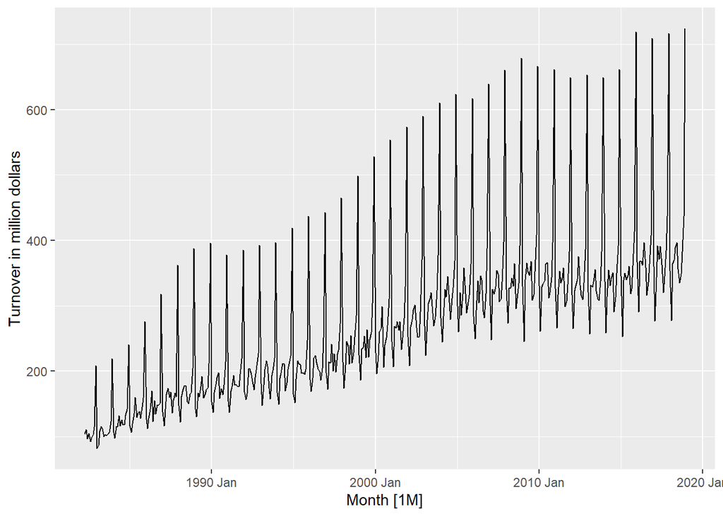

```r
myseries %>%
  autoplot(Turnover) +
  ylab(label = "Turnover in million dollars")
```

From the above plot we can observe the following things-

- there is an increasing trend
- there is seasonality in the data
- there is a multiplicative relation between trend and seasonality i.e. seasonality is increasing with trend.
- also, the data is not stationary.

# Explanation of transformations and differencing used. You should use a unit-root test as part of the discussion. [5 marks]

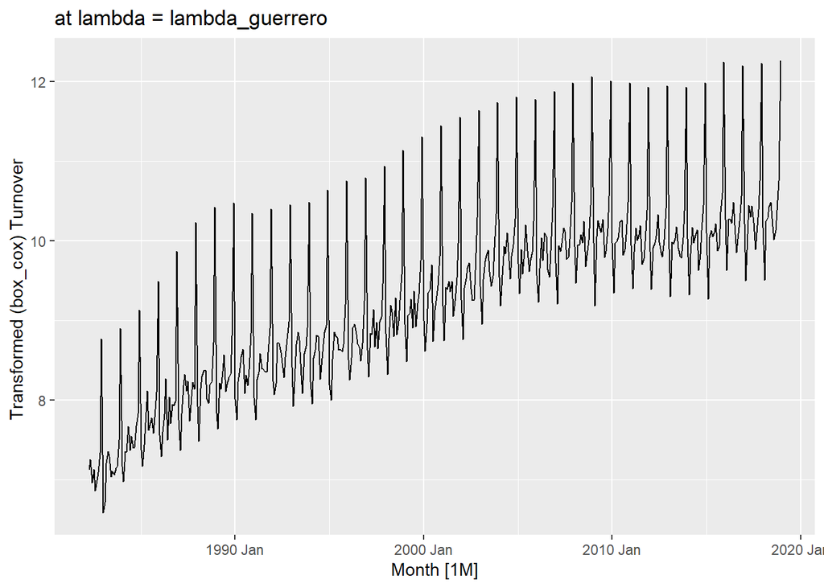

```r
lambda <- myseries %>%
  features(Turnover, features = guerrero) %>%
  pull(lambda_guerrero)

  myseries %>%
  autoplot(box_cox(Turnover, lambda)) +
  ggtitle("at lambda = lambda_guerrero") +
    ylab(label = "Transformed (box_cox) Turnover ")
```

```r
  myseries %>%
  features(box_cox(Turnover, lambda) %>% difference(lag=12), unitroot_kpss)
```

```
## # A tibble: 1 × 4
##   State    Industry          kpss_stat kpss_pvalue
##   <chr>    <chr>                 <dbl>       <dbl>
## 1 Victoria Department stores      1.98        0.01
```

```r
   myseries %>%
  features(box_cox(Turnover, lambda) %>% difference(lag=12) %>% difference(), unitroot_kpss)
```

```
## # A tibble: 1 × 4
##   State    Industry          kpss_stat kpss_pvalue
##   <chr>    <chr>                 <dbl>       <dbl>
## 1 Victoria Department stores   0.00918         0.1
```

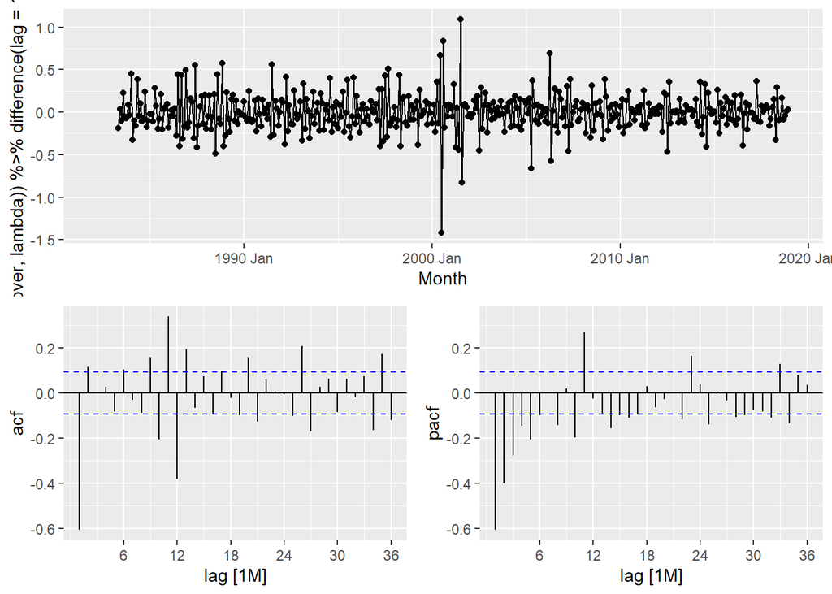

```r
  myseries %>%
  gg_tsdisplay((box_cox(Turnover, lambda)) %>%
                 difference(lag = 12) %>%
                 difference(),
               plot_type = "partial",
               lag_max = 36)
```

**TRANSFORMATION**

In the given data plot, we can easily see that seasonality is also increasing with the trend (multiplicative relation), hence our data needs transformation. So I did **box_cox** transformation with optimal value of lambda using **guerrero** method.

**DIFFERENCING**

Since our data is not stationary, therefore we have to apply differencing to make it stationary. We know that our data is monthly data and seasonal, so we apply seasonal difference and then we do **unitroot_kpss** test to know whether we need another difference or not. After the test, I got **kpss_value = 0.01** which is less than **0.05** and therefore we will reject the **null hypothesis of stationarity** and hence we will have to do one more difference i.e. **first first-order difference** and then we will again do the unitroot_kpss test. This time I got kpss_value 0.1 which is greater than 0.05 and hence I can say now that my data is stationary.

So now we can say that our data is stationary.

# A description of the methodology used to create a short-list of appropriate ARIMA models and ETS models. Include discussion of AIC values as well as results from applying the models to a test-set consisting of the last 24 months of the data provided. [6 marks]

```r
fit <- myseries %>%
  filter(year(Month) <= 2016) %>%
  model(
    ARIMA310010 = ARIMA(box_cox(Turnover, lambda) ~ 0 + pdq(3, 1, 0) + PDQ(0, 1, 0)),
    ARIMA011011 = ARIMA(box_cox(Turnover, lambda) ~ 0 + pdq(0, 1, 1) + PDQ(0, 1, 1)),
    ARIMA111111 = ARIMA(box_cox(Turnover, lambda) ~ 0 + pdq(1, 1, 1) + PDQ(1, 1, 1)),
    ARIMA211111 = ARIMA(box_cox(Turnover, lambda) ~ 0 + pdq(2, 1, 0) + PDQ(1, 1, 0)),
    auto = ARIMA(box_cox(Turnover, lambda))
  )


glance(fit)
```

```
## # A tibble: 5 × 10
##   State    Industry      .model sigma2 log_lik   AIC  AICc   BIC ar_ro…¹ ma_ro…²
##   <chr>    <chr>         <chr>   <dbl>   <dbl> <dbl> <dbl> <dbl> <list>  <list>
## 1 Victoria Department s… ARIMA… 0.0253    171. -334. -333. -318. <cpl>   <cpl>
## 2 Victoria Department s… ARIMA… 0.0186    228. -451. -451. -439. <cpl>   <cpl>
## 3 Victoria Department s… ARIMA… 0.0175    242. -473. -473. -453. <cpl>   <cpl>
## 4 Victoria Department s… ARIMA… 0.0233    186. -364. -364. -348. <cpl>   <cpl>
## 5 Victoria Department s… auto   0.0175    242. -471. -471. -447. <cpl>   <cpl>
## # … with abbreviated variable names ¹ar_roots, ²ma_roots
```

```r
fit2 <- myseries %>%
  filter(year(Month) <= 2016) %>%
  model(
    AAM = ETS(box_cox(Turnover, lambda) ~ error("A") + trend("A") + season("M")),
    AMM = ETS(box_cox(Turnover, lambda) ~ error("A") + trend("M") + season("M")),
    ANM = ETS(box_cox(Turnover, lambda) ~ error("A") + trend("N") + season("M")),
    AMA = ETS(box_cox(Turnover, lambda) ~ error("A") + trend("M") + season("A")),
    auto = ETS(box_cox(Turnover, lambda))
  )

glance(fit2)
```

```
## # A tibble: 5 × 11
##   State    Industry  .model sigma2 log_lik   AIC  AICc   BIC    MSE   AMSE   MAE
##   <chr>    <chr>     <chr>   <dbl>   <dbl> <dbl> <dbl> <dbl>  <dbl>  <dbl> <dbl>
## 1 Victoria Departme… AAM    0.0185   -418.  870.  871.  938. 0.0178 0.0177 0.101
## 2 Victoria Departme… AMM    0.0184   -417.  868.  870.  937. 0.0177 0.0175 0.101
## 3 Victoria Departme… ANM    0.0201   -437.  903.  904.  964. 0.0195 0.0193 0.106
## 4 Victoria Departme… AMA    0.0185   -418.  870.  872.  939. 0.0178 0.0177 0.101
## 5 Victoria Departme… auto   0.0183   -416.  866.  867.  934. 0.0176 0.0175 0.102
```

```r
fc_ARIMA <- fit %>%
  forecast(h = "2 years") %>%
  accuracy(myseries)

fc_ETS <- fit2 %>%
  forecast(h = "2 years") %>%
  accuracy(myseries)



fc_ARIMA
```

```
## # A tibble: 5 × 12
##   .model  State Indus…¹ .type     ME  RMSE   MAE    MPE  MAPE  MASE RMSSE   ACF1
##   <chr>   <chr> <chr>   <chr>  <dbl> <dbl> <dbl>  <dbl> <dbl> <dbl> <dbl>  <dbl>
## 1 ARIMA0… Vict… Depart… Test  -1.66   10.7  8.71 -0.543  2.33 0.643 0.609 0.0122
## 2 ARIMA1… Vict… Depart… Test  -0.401  10.3  8.05 -0.257  2.19 0.593 0.586 0.0363
## 3 ARIMA2… Vict… Depart… Test   3.71   12.2  9.59  0.884  2.53 0.708 0.698 0.0484
## 4 ARIMA3… Vict… Depart… Test  13.6    20.2 16.8   3.25   4.23 1.24  1.16  0.372
## 5 auto    Vict… Depart… Test  -0.479  10.2  8.04 -0.276  2.19 0.593 0.586 0.0350
## # … with abbreviated variable name ¹Industry
```

```r
fc_ETS
```

```
## # A tibble: 5 × 12
##   .model State   Indus…¹ .type     ME  RMSE   MAE   MPE  MAPE  MASE RMSSE   ACF1
##   <chr>  <chr>   <chr>   <chr>  <dbl> <dbl> <dbl> <dbl> <dbl> <dbl> <dbl>  <dbl>
## 1 AAM    Victor… Depart… Test  -11.1   17.5  13.7 -2.78  3.43 1.01  1.00  0.0495
## 2 AMA    Victor… Depart… Test   -6.10  12.8  10.4 -1.64  2.73 0.769 0.731 0.0423
## 3 AMM    Victor… Depart… Test   -7.43  14.7  11.4 -1.85  2.86 0.843 0.839 0.0257
## 4 ANM    Victor… Depart… Test   11.5   16.0  12.9  2.85  3.24 0.948 0.912 0.131
## 5 auto   Victor… Depart… Test   -7.11  13.2  10.8 -1.90  2.83 0.796 0.756 0.0460
## # … with abbreviated variable name ¹Industry
```

**ARIMA MODELS**

Since we have done two differences, first seasonal difference and then a normal first order difference, therefore our d = 1 and D is also equal to 1.

**ETS MODELS**

While fitting ETS model, since the data has trend, seasonality and a multiplicative relation between trend and seasonality. Therefore my models are as follows-

- ETS(A,A,M) taking error and trend to be additive and season to be multiplicative.
- ETS(A,M,M) taking error to be additive and trend and season to be multiplicative.
- ETS(A,N,M) taking error to be additive and no trend with multiplicative seasonality.
- ETS(A,M,A) taking error and seasonality to be additive and trend to be multiplicative.
- ETS(auto) which is coming to be ETS(A,A,A)

# Choose one ARIMA model and one ETS model based on this analysis and show parameter estimates, residual diagnostics, forecasts and prediction intervals for both models. Diagnostic checking for both models should include ACF graphs and the Ljung-Box test. [8 marks]

- ARIMA(auto, ARIMA111112) has RMSE = 10.24
- ARIMA111111 has RMSE = 10.25

If we consider AICc values for both the models, - ARIMA(auto) has AIcc = -470.9 - ARIMA(111111) has AICc = -472.9

Since, difference in AICc is more as compared to RMSE values, therefore, I will be using AICc to select my best ARIMA model which is **ARIMA111111**.

```r
fit %>%
  select(ARIMA111111) %>%
  report()
```

```
## Series: Turnover
## Model: ARIMA(1,1,1)(1,1,1)[12]
## Transformation: box_cox(Turnover, lambda)
##
## Coefficients:
##           ar1      ma1    sar1     sma1
##       -0.2045  -0.8185  0.2551  -0.8169
## s.e.   0.0550   0.0306  0.0692   0.0455
##
## sigma^2 estimated as 0.01745:  log likelihood=241.56
## AIC=-473.11   AICc=-472.96   BIC=-453.1
```

```r
fit2 %>%
  select(auto) %>%
  report()
```

```
## Series: Turnover
## Model: ETS(A,A,A)
## Transformation: box_cox(Turnover, lambda)
##   Smoothing parameters:
##     alpha = 0.1061106
##     beta  = 0.006387994
##     gamma = 0.2428435
##
##   Initial states:
##     l[0]       b[0]       s[0]      s[-1]      s[-2]    s[-3]     s[-4]
##  7.05576 0.01992411 -0.2043568 -0.6071502 -0.4409827 1.651696 0.1543157
##        s[-5]      s[-6]      s[-7]      s[-8]      s[-9]    s[-10]      s[-11]
##  -0.05680299 -0.1673019 -0.2446274 -0.0943167 -0.1311903 0.1571278 -0.01641092
##
##   sigma^2:  0.0183
##
##      AIC     AICc      BIC
## 865.6136 867.1474 934.1760
```

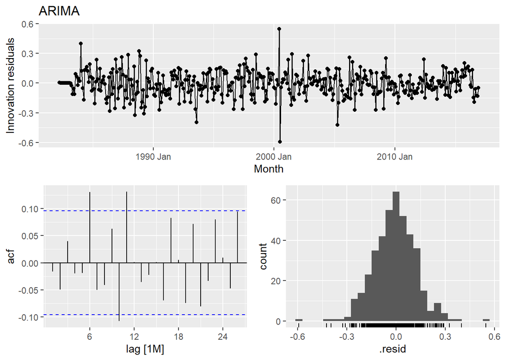

```r
fit %>%
  select(ARIMA111111) %>%
  gg_tsresiduals() +
  labs(title = "ARIMA")
```

```r
fit %>%
  select(ARIMA111111) %>%
  augment() %>%
  features(.innov, ljung_box, lag = 24)
```

```
## # A tibble: 1 × 3
##   .model      lb_stat lb_pvalue
##   <chr>         <dbl>     <dbl>
## 1 ARIMA111111    42.1    0.0126
```

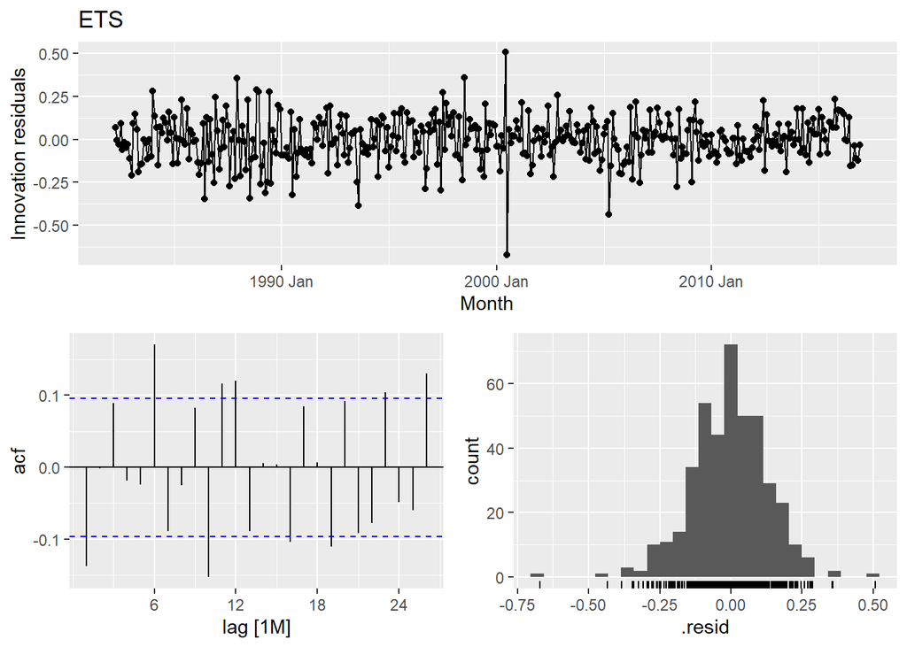

```r
fit2 %>%
  select(auto) %>%
  gg_tsresiduals() +
  labs(title = "ETS")
```

```r
fit2 %>%
  select(auto) %>%
  augment() %>%
  features(.innov, ljung_box, lag = 24)
```

```
## # A tibble: 1 × 3
##   .model lb_stat     lb_pvalue
##   <chr>    <dbl>         <dbl>
## 1 auto      85.2 0.00000000899
```

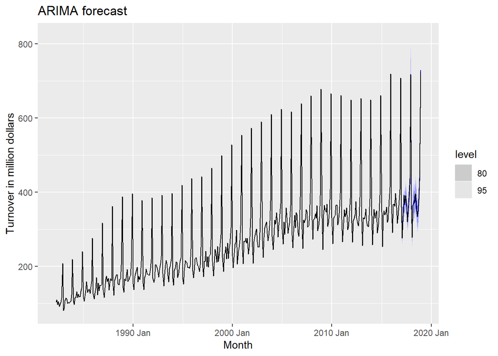

```r
ARIMA_fc <- fit %>%
  forecast(h = "2 years") %>%
  filter(.model == "ARIMA111111")

ARIMA_fc %>%
  autoplot(myseries) +
  labs(title = "ARIMA forecast") +
  ylab(label = "Turnover in million dollars")
```

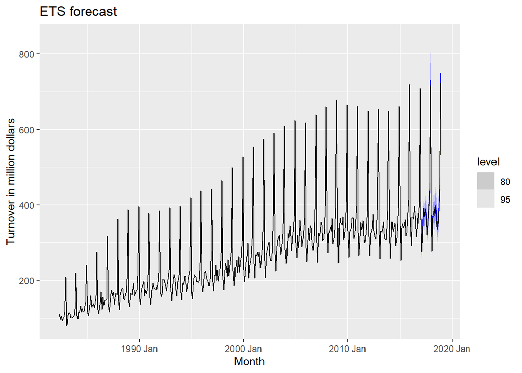

```r
ETS_fc <- fit2 %>%
  forecast(h = "2 years") %>%
  filter(.model == "auto")

ETS_fc %>%
autoplot(myseries) +
  labs(title = "ETS forecast") +
  ylab(label = "Turnover in million dollars")
```

```r
ARIMA_fc %>%
  hilo(level = 95) %>%
  mutate(
    lower = `95%`$lower,
    upper = `95%`$upper
  )
```

```
## # A tsibble: 24 x 9 [1M]
## # Key:       State, Industry, .model [1]
##    State   Indus…¹ .model    Month         Turnover .mean                  `95%`
##    <chr>   <chr>   <chr>     <mth>           <dist> <dbl>                 <hilo>
##  1 Victor… Depart… ARIMA… 2017 Jan  t(N(10, 0.017))  362. [328.7498, 396.4392]95
##  2 Victor… Depart… ARIMA… 2017 Feb t(N(9.6, 0.017))  287. [259.7970, 315.7081]95
##  3 Victor… Depart… ARIMA… 2017 Mar  t(N(10, 0.018))  361. [327.6996, 396.4863]95
##  4 Victor… Depart… ARIMA… 2017 Apr  t(N(10, 0.018))  371. [336.5080, 407.5462]95
##  5 Victor… Depart… ARIMA… 2017 May  t(N(10, 0.019))  366. [331.7726, 402.8257]95
##  6 Victor… Depart… ARIMA… 2017 Jun  t(N(10, 0.019))  390. [352.8616, 428.4091]95
##  7 Victor… Depart… ARIMA… 2017 Jul   t(N(10, 0.02))  370. [334.9287, 408.1449]95
##  8 Victor… Depart… ARIMA… 2017 Aug  t(N(9.9, 0.02))  327. [294.7829, 361.5035]95
##  9 Victor… Depart… ARIMA… 2017 Sep   t(N(10, 0.02))  341. [307.3401, 377.0995]95
## 10 Victor… Depart… ARIMA… 2017 Oct  t(N(10, 0.021))  373. [336.6635, 412.5718]95
## # … with 14 more rows, 2 more variables: lower <dbl>, upper <dbl>, and
## #   abbreviated variable name ¹Industry
```

```r
ETS_fc %>%
  hilo(level = 95) %>%
  mutate(
    lower = `95%`$lower,
    upper = `95%`$upper
  )
```

```
## # A tsibble: 24 x 9 [1M]
## # Key:       State, Industry, .model [1]
##    State   Indus…¹ .model    Month         Turnover .mean                  `95%`
##    <chr>   <chr>   <chr>     <mth>           <dist> <dbl>                 <hilo>
##  1 Victor… Depart… auto   2017 Jan  t(N(10, 0.018))  364. [329.9124, 399.6035]95
##  2 Victor… Depart… auto   2017 Feb t(N(9.6, 0.019))  286. [258.1422, 315.6234]95
##  3 Victor… Depart… auto   2017 Mar  t(N(10, 0.019))  361. [326.8433, 397.0027]95
##  4 Victor… Depart… auto   2017 Apr  t(N(10, 0.019))  374. [338.4931, 411.2739]95
##  5 Victor… Depart… auto   2017 May  t(N(10, 0.019))  368. [332.8070, 405.2361]95
##  6 Victor… Depart… auto   2017 Jun   t(N(10, 0.02))  388. [351.2557, 427.6659]95
##  7 Victor… Depart… auto   2017 Jul   t(N(10, 0.02))  377. [340.5358, 415.8224]95
##  8 Victor… Depart… auto   2017 Aug  t(N(10, 0.021))  333. [300.1951, 368.9110]95
##  9 Victor… Depart… auto   2017 Sep  t(N(10, 0.021))  346. [311.0579, 382.6289]95
## 10 Victor… Depart… auto   2017 Oct  t(N(10, 0.022))  382. [343.8070, 422.4193]95
## # … with 14 more rows, 2 more variables: lower <dbl>, upper <dbl>, and
## #   abbreviated variable name ¹Industry
```

From the above **ACF plot of ARIMA model**, we can see that it is not white noise with 3 significant lags and since we are getting lb_value **0.01 which less than 0.05**, therefore here we can say that it is significantly different from white noise.

From the above **ACF plot of ETS model**, we can see that it is not white noise with almost 6 significant lags and since we are getting lb_value **8.99e-09 which is very less than 0.05**, therefore here we can say that it is significantly different from white noise.

# Comparison of the results from each of your preferred models. Which method do you think gives the better forecasts? Explain with reference to the test-set. [2 marks]

```r
ARIMA_fc %>%
  accuracy(myseries)
```

```
## # A tibble: 1 × 12
##   .model  State Indus…¹ .type     ME  RMSE   MAE    MPE  MAPE  MASE RMSSE   ACF1
##   <chr>   <chr> <chr>   <chr>  <dbl> <dbl> <dbl>  <dbl> <dbl> <dbl> <dbl>  <dbl>
## 1 ARIMA1… Vict… Depart… Test  -0.401  10.3  8.05 -0.257  2.19 0.593 0.586 0.0363
## # … with abbreviated variable name ¹Industry
```

```r
ETS_fc %>%
  accuracy(myseries)
```

```
## # A tibble: 1 × 12
##   .model State    Indus…¹ .type    ME  RMSE   MAE   MPE  MAPE  MASE RMSSE   ACF1
##   <chr>  <chr>    <chr>   <chr> <dbl> <dbl> <dbl> <dbl> <dbl> <dbl> <dbl>  <dbl>
## 1 auto   Victoria Depart… Test  -7.11  13.2  10.8 -1.90  2.83 0.796 0.756 0.0460
## # … with abbreviated variable name ¹Industry
```

If we compare the results and try to find out which model is giving better forecasts, we can find out accuracy for both the models. The results we get after the accuracy test are as follows- - For ARIMA model, RMSE = 10.25 - For ETS model, RMSE = 13.23

So clearly, my ARIMA model is providing better forecasts as compared to ETS model.

# Apply your two chosen models to the full data set, re-estimating the parameters but not changing the model structure. Produce out-of-sample point forecasts and 80% prediction intervals for each model for two years past the end of the data provided. [4 marks]

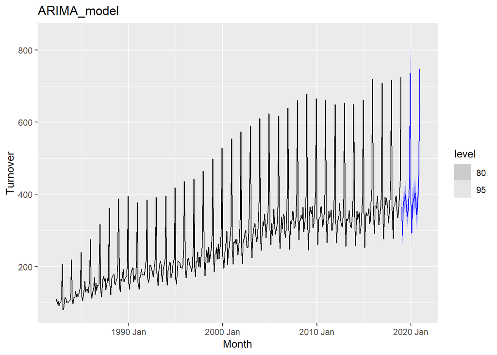

```r
final_ARIMA_fit <- myseries %>%
  model(
  final_ARIMA = ARIMA(box_cox(Turnover, lambda) ~ 0 + pdq(1, 1, 1) + PDQ(1, 1, 1))
  )

final_ARIMA_fc <- final_ARIMA_fit %>%
  forecast(h = "2 years")

final_ARIMA_fc %>%
  autoplot(myseries) +
  labs(title = "ARIMA_model")
```

```r
final_ARIMA_fc %>%
  hilo(level = 80) %>%
  mutate(
    lower = `80%`$lower,
    upper = `80%`$upper
  )
```

```
## # A tsibble: 24 x 9 [1M]
## # Key:       State, Industry, .model [1]
##    State   Indus…¹ .model    Month         Turnover .mean                  `80%`
##    <chr>   <chr>   <chr>     <mth>           <dist> <dbl>                 <hilo>
##  1 Victor… Depart… final… 2019 Jan  t(N(10, 0.017))  364. [342.5189, 386.2132]80
##  2 Victor… Depart… final… 2019 Feb t(N(9.6, 0.017))  287. [269.4873, 305.4033]80
##  3 Victor… Depart… final… 2019 Mar  t(N(10, 0.017))  367. [344.7977, 389.5026]80
##  4 Victor… Depart… final… 2019 Apr  t(N(10, 0.018))  381. [357.9130, 404.4766]80
##  5 Victor… Depart… final… 2019 May  t(N(10, 0.018))  385. [361.9554, 409.4753]80
##  6 Victor… Depart… final… 2019 Jun  t(N(10, 0.018))  399. [374.5933, 423.9917]80
##  7 Victor… Depart… final… 2019 Jul  t(N(10, 0.019))  374. [350.2271, 397.4751]80
##  8 Victor… Depart… final… 2019 Aug  t(N(10, 0.019))  339. [317.5100, 361.5681]80
##  9 Victor… Depart… final… 2019 Sep   t(N(10, 0.02))  353. [330.6555, 376.6637]80
## 10 Victor… Depart… final… 2019 Oct   t(N(10, 0.02))  388. [363.4460, 413.6497]80
## # … with 14 more rows, 2 more variables: lower <dbl>, upper <dbl>, and
## #   abbreviated variable name ¹Industry
```

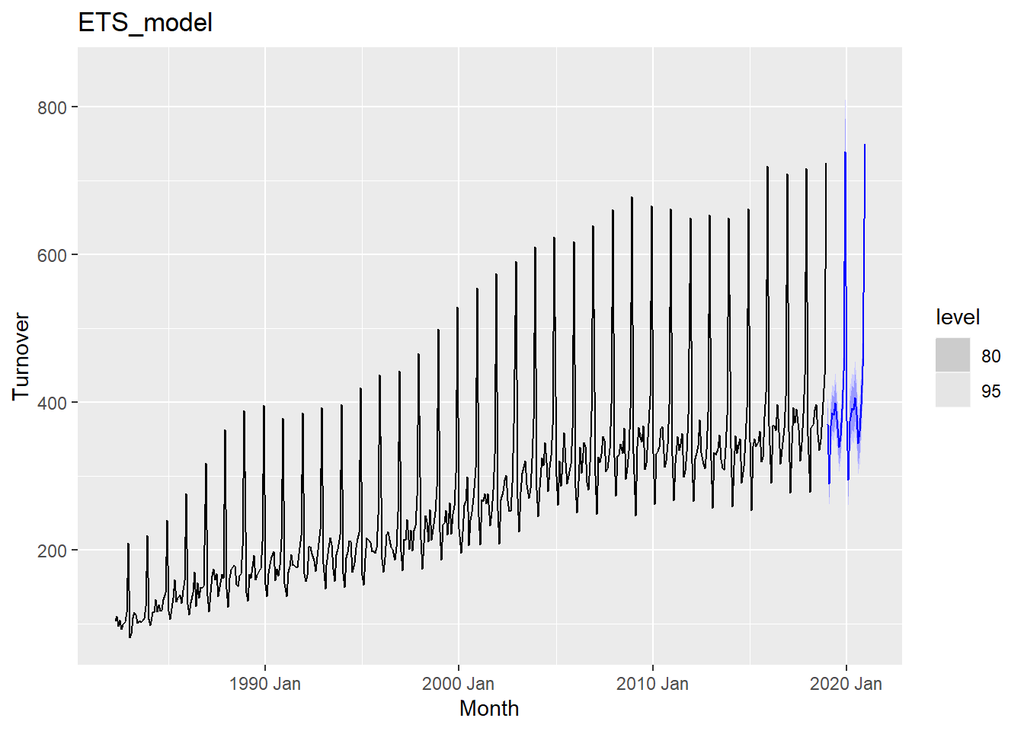

```r
final_ETS_fit <- myseries %>%
  model(
    final_ETS = ETS(box_cox(Turnover, lambda) ~ error("A") + trend("A") + season("A"))
  )


final_ETS_fc <- final_ETS_fit %>%
  forecast(h = "2 years")

final_ETS_fc %>%
  autoplot(myseries) +
  labs(title = "ETS_model")
```

```r
final_ETS_fc %>%
  hilo(level = 80) %>%
  mutate(
    lower = `80%`$lower,
    upper = `80%`$upper
  )
```

```
## # A tsibble: 24 x 9 [1M]
## # Key:       State, Industry, .model [1]
##    State   Indus…¹ .model    Month         Turnover .mean                  `80%`
##    <chr>   <chr>   <chr>     <mth>           <dist> <dbl>                 <hilo>
##  1 Victor… Depart… final… 2019 Jan  t(N(10, 0.018))  369. [346.7974, 392.0705]80
##  2 Victor… Depart… final… 2019 Feb t(N(9.6, 0.018))  289. [270.7716, 308.0070]80
##  3 Victor… Depart… final… 2019 Mar  t(N(10, 0.018))  367. [344.8242, 390.5573]80
##  4 Victor… Depart… final… 2019 Apr  t(N(10, 0.018))  385. [361.6242, 409.5815]80
##  5 Victor… Depart… final… 2019 May  t(N(10, 0.019))  383. [358.7260, 406.8166]80
##  6 Victor… Depart… final… 2019 Jun  t(N(10, 0.019))  399. [374.0783, 424.3547]80
##  7 Victor… Depart… final… 2019 Jul   t(N(10, 0.02))  377. [352.5668, 400.9938]80
##  8 Victor… Depart… final… 2019 Aug   t(N(10, 0.02))  339. [316.5113, 361.3742]80
##  9 Victor… Depart… final… 2019 Sep   t(N(10, 0.02))  354. [330.7515, 377.8464]80
## 10 Victor… Depart… final… 2019 Oct  t(N(10, 0.021))  390. [364.7839, 416.4901]80
## # … with 14 more rows, 2 more variables: lower <dbl>, upper <dbl>, and
## #   abbreviated variable name ¹Industry
```

# Obtain up-to-date data from the ABS website (https://www.abs.gov.au/statistics/industry/retail-and-wholesale-trade/retail-trade-australia Table 11). You may need to use the previous release of data, rather than the latest release. Compare your forecasts with the actual numbers. How well did you do? [5 marks]

```r
url <- paste0("https://www.abs.gov.au/statistics/industry/retail-and-wholesale-trade/retail-trade-australia/feb-2023/8501011.xlsx")

myseries3 <- read_abs_url(url) %>%
  filter(series_id == "A3349641R") %>%
  select(date, value) %>%
  filter(year(date) >= 2019, year(date) <= 2020)

myseries_ARIMA <- as.data.frame(cbind(myseries3$value, final_ARIMA_fc$.mean)) %>%
  rename(Actual = "V1",
         Forecasted = "V2")


myseries_ETS <- as.data.frame(cbind(myseries3$value, final_ETS_fc$.mean)) %>%
  rename(Actual = "V1",
         Forecasted = "V2")


RMSE_ARIMA <- sqrt(mean((myseries_ARIMA$Forecasted - myseries_ARIMA$Actual)^2))
RMSE_ETS <- sqrt(mean((myseries_ETS$Forecasted - myseries_ETS$Actual)^2))
```

In order to check my models’ performances, I compared actual values with my forecasted values and calculated RMSE for both ARIMA and ETS models. The result I got is as follows-

- For ARIMA model, RMSE = 66.662
- For ETS model, RMSE = 67.290

So I can say my both the models performed well but ARIMA is doing little better.

# A discussion of benefits and limitations of the models for your data. [3 marks]

**Benefits of ARIMA and ETS model** - Both ARIMA and ETS models are capable of capturing time dependent patterns - Both the models are easily interpretable. - Both the models provide good accuracy as we saw above that both the models provided almost similar accuracy (ARIMA_RMSE = 66.66 and ETS_RMSE = 67.29)

**Limitations of ARIMA and ETS model** - Both the models perform well while capturing single-time dependent patterns but they find it difficult to handle more complex time series patterns. - In both the models, selection of parameters is very complex. In ARIMA model, selecting correct value for AR, I and MA and in ETS model, selecting correct error, trend and season is very important. - To fit ARIMA model, the data has to be stationary and if its not, then you have to transform the data and do differencing to make the data stationary.